# CUNY Data 607 – Week 5 Assignment – Tidying and Transforming Data

Emilie M Bolduc

10/1/2017

# Assignment

1. Create a .CSV file (or optionally, a MySQL database!) that includes all of the information above. You’re encouraged to use a “wide” structure similar to how the information appears above, so that you can practice tidying and transformations as described below.
2. Read the information from your .CSV file into R, and use tidyr and dplyr as needed to tidy and transform your data.
3. Perform analysis to compare the arrival delays for the two airlines.

# Solution

### Read CSV

Took the data provided and typed it into a CSV table that I then uploaded into R.

```r
library(readr)
Airline_delays <- read_csv("~/Documents/CUNY Data 607/data/airlines/Airline_delays.csv")
Airline_delays
```

```
## # A tibble: 5 x 7
##        X1      X2 `Los Angeles` Phoenix `San Diego` `San Francisco`
##     <chr>   <chr>         <int>   <int>       <int>           <int>
## 1  ALASKA on time           497     221         212             503
## 2    <NA> delayed            62      12          20             102
## 3    <NA>    <NA>            NA      NA          NA              NA
## 4 AM WEST on time           694    4840         383             320
## 5    <NA> delayed           117     415          65             129
## # ... with 1 more variables: Seattle <int>
```

### Tidy Data

#### 1. Fill first column with complete row names

The carrier names in the first column were not populated across all rows, so needed to fill the remaining rows in that column with the Carrier name.

```r
library(tidyr)
Airline <- Airline_delays %>% fill(X1)
Airline
```

```
## # A tibble: 5 x 7
##        X1      X2 `Los Angeles` Phoenix `San Diego` `San Francisco`
##     <chr>   <chr>         <int>   <int>       <int>           <int>
## 1  ALASKA on time           497     221         212             503
## 2  ALASKA delayed            62      12          20             102
## 3  ALASKA    <NA>            NA      NA          NA              NA
## 4 AM WEST on time           694    4840         383             320
## 5 AM WEST delayed           117     415          65             129
## # ... with 1 more variables: Seattle <int>
```

Reference: https://blog.rstudio.com/2015/09/13/tidyr-0-3-0/

#### 2. Remove rows with NAs

There was an uncessary empty row in the original CSV file which appeared as NA when uploaded into R, so had to remove it.

```r
Airline <- na.omit(Airline)
```

#### 3. Make observations from variables with tidyr ‘gather’ function

i.e. Change the City column data into observations rows.

```r
Airline <- gather(Airline, "City", "n", 3:7)
Airline
```

```
## # A tibble: 20 x 4
##         X1      X2          City     n
##      <chr>   <chr>         <chr> <int>
##  1  ALASKA on time   Los Angeles   497
##  2  ALASKA delayed   Los Angeles    62
##  3 AM WEST on time   Los Angeles   694
##  4 AM WEST delayed   Los Angeles   117
##  5  ALASKA on time       Phoenix   221
##  6  ALASKA delayed       Phoenix    12
##  7 AM WEST on time       Phoenix  4840
##  8 AM WEST delayed       Phoenix   415
##  9  ALASKA on time     San Diego   212
## 10  ALASKA delayed     San Diego    20
## 11 AM WEST on time     San Diego   383
## 12 AM WEST delayed     San Diego    65
## 13  ALASKA on time San Francisco   503
## 14  ALASKA delayed San Francisco   102
## 15 AM WEST on time San Francisco   320
## 16 AM WEST delayed San Francisco   129
## 17  ALASKA on time       Seattle  1841
## 18  ALASKA delayed       Seattle   305
## 19 AM WEST on time       Seattle   201
## 20 AM WEST delayed       Seattle    61
```

#### 4. Make variables from observations with tidyr ‘spread’ function

i.e. Take the “On Time” and “Delayed” row variables and turn them into observations.

```r
Airline <- spread(Airline, "X2", "n")
Airline
```

```
## # A tibble: 10 x 4
##         X1          City delayed `on time`
##  *   <chr>         <chr>   <int>     <int>
##  1  ALASKA   Los Angeles      62       497
##  2  ALASKA       Phoenix      12       221
##  3  ALASKA     San Diego      20       212
##  4  ALASKA San Francisco     102       503
##  5  ALASKA       Seattle     305      1841
##  6 AM WEST   Los Angeles     117       694
##  7 AM WEST       Phoenix     415      4840
##  8 AM WEST     San Diego      65       383
##  9 AM WEST San Francisco     129       320
## 10 AM WEST       Seattle      61       201
```

#### 5. Change column names with ‘dplyr’ fucntions

```r
library(dplyr)
Airline <- dplyr::rename(Airline, Carrier = X1)
Airline <- dplyr::rename(Airline, Delayed = delayed)
Airline <- dplyr::rename(Airline, On_Time = 'on time')
Airline
```

```
## # A tibble: 10 x 4
##    Carrier          City Delayed On_Time
##  *   <chr>         <chr>   <int>   <int>
##  1  ALASKA   Los Angeles      62     497
##  2  ALASKA       Phoenix      12     221
##  3  ALASKA     San Diego      20     212
##  4  ALASKA San Francisco     102     503
##  5  ALASKA       Seattle     305    1841
##  6 AM WEST   Los Angeles     117     694
##  7 AM WEST       Phoenix     415    4840
##  8 AM WEST     San Diego      65     383
##  9 AM WEST San Francisco     129     320
## 10 AM WEST       Seattle      61     201
```

I still find the following function quicker and easier…

> colnames(Airline)<- c(“Carrier”,“City”,“Delayed”, “On Time”)

### Perform Analysis with ‘dplyr’

Taking a look at the data:

```r
dplyr::glimpse(Airline)
```

```
## Observations: 10
## Variables: 4
## $ Carrier <chr> "ALASKA", "ALASKA", "ALASKA", "ALASKA", "ALASKA", "AM ...
## $ City    <chr> "Los Angeles", "Phoenix", "San Diego", "San Francisco"...
## $ Delayed <int> 62, 12, 20, 102, 305, 117, 415, 65, 129, 61
## $ On_Time <int> 497, 221, 212, 503, 1841, 694, 4840, 383, 320, 201
```

Look at the number of delays by Carrier:

```r
select(Airline, Carrier, Delayed)
```

```
## # A tibble: 10 x 2
##    Carrier Delayed
##  *   <chr>   <int>
##  1  ALASKA      62
##  2  ALASKA      12
##  3  ALASKA      20
##  4  ALASKA     102
##  5  ALASKA     305
##  6 AM WEST     117
##  7 AM WEST     415
##  8 AM WEST      65
##  9 AM WEST     129
## 10 AM WEST      61
```

Mean and median of all Delays:

```r
dplyr::summarise(Airline, Mean = mean(Delayed), Median = median(Delayed))
```

```
## # A tibble: 1 x 2
##    Mean Median
##   <dbl>  <dbl>
## 1 128.8   83.5
```

Look at the number of delays in descending order:

```r
dplyr::arrange(Airline, desc(Delayed))
```

```
## # A tibble: 10 x 4
##    Carrier          City Delayed On_Time
##      <chr>         <chr>   <int>   <int>
##  1 AM WEST       Phoenix     415    4840
##  2  ALASKA       Seattle     305    1841
##  3 AM WEST San Francisco     129     320
##  4 AM WEST   Los Angeles     117     694
##  5  ALASKA San Francisco     102     503
##  6 AM WEST     San Diego      65     383
##  7  ALASKA   Los Angeles      62     497
##  8 AM WEST       Seattle      61     201
##  9  ALASKA     San Diego      20     212
## 10  ALASKA       Phoenix      12     221
```

Number of delays in ascending order by Carrier:

```r
dplyr::arrange(Airline, Carrier, Delayed)
```

```
## # A tibble: 10 x 4
##    Carrier          City Delayed On_Time
##      <chr>         <chr>   <int>   <int>
##  1  ALASKA       Phoenix      12     221
##  2  ALASKA     San Diego      20     212
##  3  ALASKA   Los Angeles      62     497
##  4  ALASKA San Francisco     102     503
##  5  ALASKA       Seattle     305    1841
##  6 AM WEST       Seattle      61     201
##  7 AM WEST     San Diego      65     383
##  8 AM WEST   Los Angeles     117     694
##  9 AM WEST San Francisco     129     320
## 10 AM WEST       Phoenix     415    4840
```

The mean and sum of delays by Carrier:

```r
Carrier <- Airline %>% group_by(Carrier) %>%
  summarise(mean = mean(Delayed), sum = sum(Delayed), n = n())
Carrier
```

```
## # A tibble: 2 x 4
##   Carrier  mean   sum     n
##     <chr> <dbl> <int> <int>
## 1  ALASKA 100.2   501     5
## 2 AM WEST 157.4   787     5
```

The mean and sum of delays by City:

```r
City <- Airline %>% group_by(City) %>%
  summarise(mean = mean(Delayed), sum = sum(Delayed)) %>%
  arrange(desc(mean))
City
```

```
## # A tibble: 5 x 3
##            City  mean   sum
##           <chr> <dbl> <int>
## 1       Phoenix 213.5   427
## 2       Seattle 183.0   366
## 3 San Francisco 115.5   231
## 4   Los Angeles  89.5   179
## 5     San Diego  42.5    85
```

### Visualize the Analysis

Create table to use for visualizing data:

```r
CityCarrier <- Airline %>% group_by(City, Carrier) %>%
  summarise(mean = mean(Delayed), sum = sum(Delayed))
```

#### Carrier Delays By City

```r
library(scales)
```

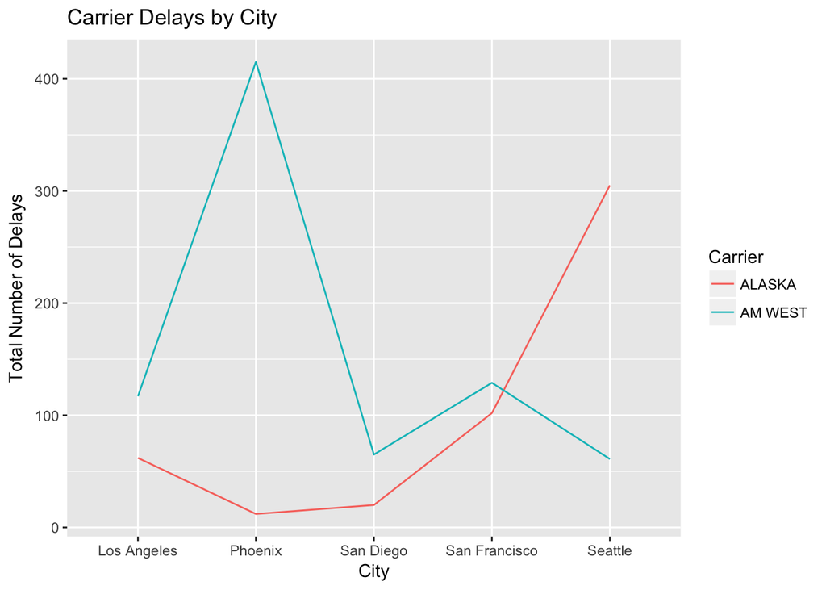

```r
library(ggplot2)
LineGraph <- ggplot(CityCarrier, aes(x = City, y = mean))
LineGraph <- LineGraph + geom_line(aes(color=factor(Carrier), group = Carrier))
LineGraph <- LineGraph + scale_color_discrete(name = "Carrier")
LineGraph <- LineGraph + labs(title = "Carrier Delays by City", x = "City", y = "Total Number of Delays")
LineGraph
```